# Bike sharing report

Neonard

2023-02-19

## Data Prep

#### Install and load necessary packages

### Load 12 months of bikesharing data

```r
Jan <- read.csv("C:\\Users\\NEONARD\\Documents\\R scripts\\Capstone project\\data\\202101-divvy-tripdata.csv")
Feb <- read.csv("C:\\Users\\NEONARD\\Documents\\R scripts\\Capstone project\\data\\202102-divvy-tripdata.csv")
Mar <- read.csv("C:\\Users\\NEONARD\\Documents\\R scripts\\Capstone project\\data\\202103-divvy-tripdata.csv")
Apr <- read.csv("C:\\Users\\NEONARD\\Documents\\R scripts\\Capstone project\\data\\202104-divvy-tripdata.csv")
May <- read.csv("C:\\Users\\NEONARD\\Documents\\R scripts\\Capstone project\\data\\202105-divvy-tripdata.csv")
Jun <- read.csv("C:\\Users\\NEONARD\\Documents\\R scripts\\Capstone project\\data\\202106-divvy-tripdata.csv")
Jul <- read.csv("C:\\Users\\NEONARD\\Documents\\R scripts\\Capstone project\\data\\202107-divvy-tripdata.csv")
Aug <- read.csv("C:\\Users\\NEONARD\\Documents\\R scripts\\Capstone project\\data\\202108-divvy-tripdata.csv")
Sep <- read.csv("C:\\Users\\NEONARD\\Documents\\R scripts\\Capstone project\\data\\202109-divvy-tripdata.csv")
Oct <- read.csv("C:\\Users\\NEONARD\\Documents\\R scripts\\Capstone project\\data\\202110-divvy-tripdata.csv")
Nov <- read.csv("C:\\Users\\NEONARD\\Documents\\R scripts\\Capstone project\\data\\202111-divvy-tripdata.csv")
Dec <- read.csv("C:\\Users\\NEONARD\\Documents\\R scripts\\Capstone project\\data\\202112-divvy-tripdata.csv")
```

### Merging data into a data frame

```r
triprawdata <- rbind(Jan,Feb,Mar,Apr,May,Jun,Jul,Aug,Sep,Oct,Nov,Dec)
```

### view/checking data

```r
nrow(triprawdata) #number of rows
```

```
## [1] 5595063
```

```r
ncol(triprawdata) #number of columns
```

```
## [1] 13
```

```r
dim(triprawdata)   # number rows and columns
```

```
## [1] 5595063      13
```

```r
head(triprawdata) #see the first 6 rows of the data frame
```

```
##            ride_id rideable_type          started_at            ended_at
## 1 E19E6F1B8D4C42ED electric_bike 2021-01-23 16:14:19 2021-01-23 16:24:44
## 2 DC88F20C2C55F27F electric_bike 2021-01-27 18:43:08 2021-01-27 18:47:12
## 3 EC45C94683FE3F27 electric_bike 2021-01-21 22:35:54 2021-01-21 22:37:14
## 4 4FA453A75AE377DB electric_bike 2021-01-07 13:31:13 2021-01-07 13:42:55
## 5 BE5E8EB4E7263A0B electric_bike 2021-01-23 02:24:02 2021-01-23 02:24:45
## 6 5D8969F88C773979 electric_bike 2021-01-09 14:24:07 2021-01-09 15:17:54
##           start_station_name start_station_id end_station_name end_station_id
## 1 California Ave & Cortez St            17660
## 2 California Ave & Cortez St            17660
## 3 California Ave & Cortez St            17660
## 4 California Ave & Cortez St            17660
## 5 California Ave & Cortez St            17660
## 6 California Ave & Cortez St            17660
##   start_lat start_lng end_lat end_lng member_casual
## 1  41.90034 -87.69674   41.89  -87.72        member
## 2  41.90033 -87.69671   41.90  -87.69        member
## 3  41.90031 -87.69664   41.90  -87.70        member
## 4  41.90040 -87.69666   41.92  -87.69        member
## 5  41.90033 -87.69670   41.90  -87.70        casual
## 6  41.90041 -87.69676   41.94  -87.71        casual
```

```r
tail(triprawdata) #see the last 6 rows of the data frame
```

```
##                  ride_id rideable_type          started_at            ended_at
## 5595058 92BBAB97D1683D69 electric_bike 2021-12-24 15:42:09 2021-12-24 19:29:35
## 5595059 847431F3D5353AB7 electric_bike 2021-12-12 13:36:55 2021-12-12 13:56:08
## 5595060 CF407BBC3B9FAD63 electric_bike 2021-12-06 19:37:50 2021-12-06 19:44:51
## 5595061 60BB69EBF5440E92 electric_bike 2021-12-02 08:57:04 2021-12-02 09:05:21
## 5595062 C414F654A28635B8 electric_bike 2021-12-13 09:00:26 2021-12-13 09:14:39
## 5595063 37AC57E34B2E7E97  classic_bike 2021-12-13 08:45:32 2021-12-13 08:49:09
##                  start_station_name start_station_id         end_station_name
## 5595058       Canal St & Madison St            13341
## 5595059       Canal St & Madison St            13341
## 5595060       Canal St & Madison St            13341 Kingsbury St & Kinzie St
## 5595061       Canal St & Madison St            13341  Dearborn St & Monroe St
## 5595062      Lawndale Ave & 16th St            362.0
## 5595063 Michigan Ave & Jackson Blvd     TA1309000002  Dearborn St & Monroe St
##         end_station_id start_lat start_lng  end_lat   end_lng member_casual
## 5595058                 41.88180 -87.63997 41.88000 -87.64000        casual
## 5595059                 41.88229 -87.63975 41.89000 -87.61000        casual
## 5595060   KA1503000043  41.88212 -87.64005 41.88911 -87.63886        member
## 5595061   TA1305000006  41.88196 -87.63995 41.88025 -87.62960        member
## 5595062                 41.86000 -87.72000 41.85000 -87.71000        member
## 5595063   TA1305000006  41.87785 -87.62408 41.88132 -87.62952        member
```

```r
str(triprawdata)  #see list of columns and data types
```

```
## 'data.frame':    5595063 obs. of  13 variables:
##  $ ride_id           : chr  "E19E6F1B8D4C42ED" "DC88F20C2C55F27F" "EC45C94683FE3F27" "4FA453A75AE377DB" ...
##  $ rideable_type     : chr  "electric_bike" "electric_bike" "electric_bike" "electric_bike" ...
##  $ started_at        : chr  "2021-01-23 16:14:19" "2021-01-27 18:43:08" "2021-01-21 22:35:54" "2021-01-07 13:31:13" ...
##  $ ended_at          : chr  "2021-01-23 16:24:44" "2021-01-27 18:47:12" "2021-01-21 22:37:14" "2021-01-07 13:42:55" ...
##  $ start_station_name: chr  "California Ave & Cortez St" "California Ave & Cortez St" "California Ave & Cortez St" "California Ave & Cortez St" ...
##  $ start_station_id  : chr  "17660" "17660" "17660" "17660" ...
##  $ end_station_name  : chr  "" "" "" "" ...
##  $ end_station_id    : chr  "" "" "" "" ...
##  $ start_lat         : num  41.9 41.9 41.9 41.9 41.9 ...
##  $ start_lng         : num  -87.7 -87.7 -87.7 -87.7 -87.7 ...
##  $ end_lat           : num  41.9 41.9 41.9 41.9 41.9 ...
##  $ end_lng           : num  -87.7 -87.7 -87.7 -87.7 -87.7 ...
##  $ member_casual     : chr  "member" "member" "member" "member" ...
```

```r
glimpse(triprawdata)
```

```
## Rows: 5,595,063
## Columns: 13
## $ ride_id            <chr> "E19E6F1B8D4C42ED", "DC88F20C2C55F27F", "EC45C94683…
## $ rideable_type      <chr> "electric_bike", "electric_bike", "electric_bike", …
## $ started_at         <chr> "2021-01-23 16:14:19", "2021-01-27 18:43:08", "2021…
## $ ended_at           <chr> "2021-01-23 16:24:44", "2021-01-27 18:47:12", "2021…
## $ start_station_name <chr> "California Ave & Cortez St", "California Ave & Cor…
## $ start_station_id   <chr> "17660", "17660", "17660", "17660", "17660", "17660…
## $ end_station_name   <chr> "", "", "", "", "", "", "", "", "", "Wood St & Augu…
## $ end_station_id     <chr> "", "", "", "", "", "", "", "", "", "657", "13258",…
## $ start_lat          <dbl> 41.90034, 41.90033, 41.90031, 41.90040, 41.90033, 4…
## $ start_lng          <dbl> -87.69674, -87.69671, -87.69664, -87.69666, -87.696…
## $ end_lat            <dbl> 41.89000, 41.90000, 41.90000, 41.92000, 41.90000, 4…
## $ end_lng            <dbl> -87.72000, -87.69000, -87.70000, -87.69000, -87.700…
## $ member_casual      <chr> "member", "member", "member", "member", "casual", "…
```

```r
summary(triprawdata) #statistical summary of data
```

```
##    ride_id          rideable_type       started_at          ended_at
##  Length:5595063     Length:5595063     Length:5595063     Length:5595063
##  Class :character   Class :character   Class :character   Class :character
##  Mode  :character   Mode  :character   Mode  :character   Mode  :character
##
##
##
##
##  start_station_name start_station_id   end_station_name   end_station_id
##  Length:5595063     Length:5595063     Length:5595063     Length:5595063
##  Class :character   Class :character   Class :character   Class :character
##  Mode  :character   Mode  :character   Mode  :character   Mode  :character
##
##
##
##
##    start_lat       start_lng         end_lat         end_lng
##  Min.   :41.64   Min.   :-87.84   Min.   :41.39   Min.   :-88.97
##  1st Qu.:41.88   1st Qu.:-87.66   1st Qu.:41.88   1st Qu.:-87.66
##  Median :41.90   Median :-87.64   Median :41.90   Median :-87.64
##  Mean   :41.90   Mean   :-87.65   Mean   :41.90   Mean   :-87.65
##  3rd Qu.:41.93   3rd Qu.:-87.63   3rd Qu.:41.93   3rd Qu.:-87.63
##  Max.   :42.07   Max.   :-87.52   Max.   :42.17   Max.   :-87.49
##                                   NA's   :4771    NA's   :4771
##  member_casual
##  Length:5595063
##  Class :character
##  Mode  :character
##
##
##
##
```

```r
colnames(triprawdata) #list of column names
```

```
##  [1] "ride_id"            "rideable_type"      "started_at"
##  [4] "ended_at"           "start_station_name" "start_station_id"
##  [7] "end_station_name"   "end_station_id"     "start_lat"
## [10] "start_lng"          "end_lat"            "end_lng"
## [13] "member_casual"
```

## Data transformation and cleaning

This section performs data cleaning and preparation

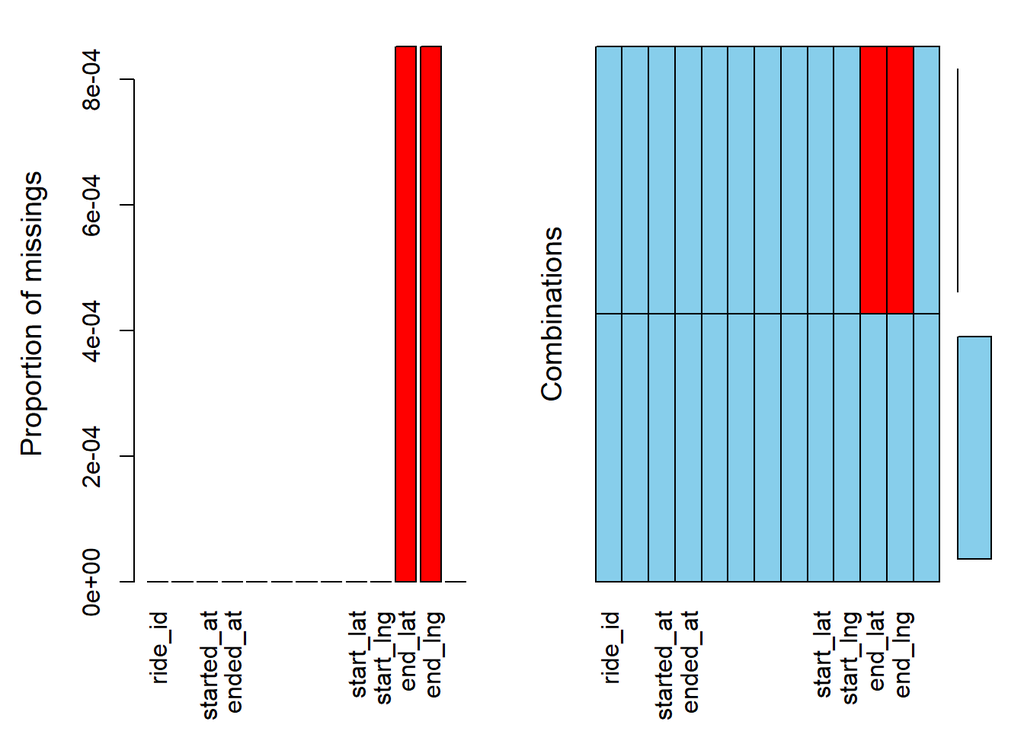

```r
aggr(triprawdata)
```

```r
colSums(is.na(triprawdata))
```

```
##            ride_id      rideable_type         started_at           ended_at
##                  0                  0                  0                  0
## start_station_name   start_station_id   end_station_name     end_station_id
##                  0                  0                  0                  0
##          start_lat          start_lng            end_lat            end_lng
##                  0                  0               4771               4771
##      member_casual
##                  0
```

```r
colSums(is.na(triprawdata)) / nrow(triprawdata)
```

```
##            ride_id      rideable_type         started_at           ended_at
##        0.000000000        0.000000000        0.000000000        0.000000000
## start_station_name   start_station_id   end_station_name     end_station_id
##        0.000000000        0.000000000        0.000000000        0.000000000
##          start_lat          start_lng            end_lat            end_lng
##        0.000000000        0.000000000        0.000852716        0.000852716
##      member_casual
##        0.000000000
```

```r
missingcells <- sum(is.na(triprawdata))
print("Missing value cells")
```

```
## [1] "Missing value cells"
```

```r
print(missingcells)
```

```
## [1] 9542
```

```r
triprawdata<- na.omit(triprawdata)
triprawdata <- janitor::remove_empty(triprawdata, which = c("cols"))
triprawdata <- janitor::remove_empty(triprawdata, which = c("rows"))


triprawdata <- triprawdata %>%
  select(-c(start_lat:end_lng))
```

### Making data consistent

Hold on! started_at & ended_at should be in datetime datatype instead of char. Convert all from char to datetime.

```r
triprawdata[['started_at']] <- ymd_hms(triprawdata[['started_at']])
triprawdata[['ended_at']] <- ymd_hms(triprawdata[['ended_at']])
```

### Adding a column for Ride length

```r
triprawdata$ride_length <- difftime(triprawdata$ended_at,
                                    triprawdata$started_at, units = "mins")
# Rename columns for better readability
triprawdata <- triprawdata %>%
  rename(ride_type = rideable_type,
         start_time = started_at,
         end_time = ended_at,
         customer_type = member_casual)
```

```r
triprawdata$day_of_the_week <- format(as.Date(triprawdata$start_time),'%a')

triprawdata$start_date <- as.Date(triprawdata$start_time)


triprawdata$month <- format(as.Date(triprawdata$start_time),'%b')

triprawdata$start_hour = format(as.POSIXct(triprawdata$start_time), "%H:%M")
triprawdata$end_hour = format(as.POSIXct(triprawdata$end_time), "%H:%M")


triprawdata$season <- ifelse (triprawdata$month %in% c('Jun','Jul','Aug'), "Summer",
                            ifelse (triprawdata$month %in% c('Sep','Oct','Nov'), "Fall",
                                    ifelse (triprawdata$month %in% c('Dec','Jan','Feb'), "Winter",
                                            ifelse (triprawdata$month %in% c('Mar','Apr','May'), "Spring", NA))))
```

### checking for trip lengths less than 0

```r
nrow(subset(triprawdata,ride_length < 0))  # 146 ride_length < 0
```

```
## [1] 146
```

```r
nrow(subset(triprawdata, start_station_name %like% "TEST"))
```

```
## [1] 0
```

```r
nrow(subset(triprawdata, start_station_name %like% "test"))
```

```
## [1] 0
```

```r
nrow(subset(triprawdata, start_station_name %like% "Test")) # zero test station
```

```
## [1] 0
```

```r
triprawdata <- triprawdata[!(triprawdata$ride_length < 0),]
```

### customer_type column has only two distinct values

```r
table(triprawdata$customer_type)
```

```
##
##  casual  member
## 2525456 3064690
```

### aggregating total trip duration by customer type

```r
setNames(aggregate(ride_length ~ customer_type, triprawdata, sum), c("customer_type", "total_trip_duration(mins)"))
```

```
##   customer_type total_trip_duration(mins)
## 1        casual             76364814 mins
## 2        member             40928329 mins
```

### Summary statistics for ride_length

```r
summary(triprawdata$ride_length)
```

```
##   Length    Class     Mode
##  5590146 difftime  numeric
```

### statistical summary of trip_duration by customer_type

```r
triprawdata %>%
  group_by(customer_type) %>%
  summarise(min_trip_duration = min(ride_length),max_trip_duration = max(ride_length),
            median_trip_duration = median(ride_length), mean_trip_duration = mean(ride_length))
```

```
## # A tibble: 2 × 5
##   customer_type min_trip_duration max_trip_duration median_trip_duration mean_…¹
##   <chr>         <drtn>            <drtn>            <drtn>               <drtn>
## 1 casual        0 mins            55944.150 mins    15.95 mins           30.238…
## 2 member        0 mins             1499.933 mins     9.60 mins           13.354…
## # … with abbreviated variable name ¹mean_trip_duration
```

### Total number of trips by customer type and day of the week

fix the order for the day_of_the_week and month variable so that they show up in the same sequence in output tables and visualizations’

```r
triprawdata$day_of_the_week <- ordered(triprawdata$day_of_the_week, levels=c("Mon", "Tue", "Wed", "Thu", "Fri", "Sat", "Sun"))
triprawdata$month <- ordered(triprawdata$month, levels=c("Jan", "Feb", "Mar", "Apr", "May", "Jun", "Jul", "Aug","Sep", "Oct", "Nov", "Dec"))
```

### daily average rides of customers

```r
triprawdata %>%
  group_by(customer_type, day_of_the_week) %>%
  summarise(number_of_rides = n(),average_duration_mins = mean(ride_length)) %>%
  arrange(customer_type, desc(number_of_rides))
```

```
## # A tibble: 14 × 4
## # Groups:   customer_type [2]
##    customer_type day_of_the_week number_of_rides average_duration_mins
##    <chr>         <ord>                     <int> <drtn>
##  1 casual        Sat                      557181 32.77079 mins
##  2 casual        Sun                      480356 35.33280 mins
##  3 casual        Fri                      363580 28.60904 mins
##  4 casual        Mon                      285992 30.28512 mins
##  5 casual        Thu                      285672 26.04953 mins
##  6 casual        Wed                      278616 26.22802 mins
##  7 casual        Tue                      274059 26.71355 mins
##  8 member        Wed                      477000 12.62713 mins
##  9 member        Tue                      465347 12.57079 mins
## 10 member        Thu                      451346 12.52743 mins
## 11 member        Fri                      446219 13.05208 mins
## 12 member        Sat                      432835 14.92358 mins
## 13 member        Mon                      416018 12.94166 mins
## 14 member        Sun                      375925 15.25226 mins
```

### Ride Analysis of customer types

count of customers

```r
triprawdata%>% group_by(customer_type)%>% summarise(n=n())%>%
  mutate(percent = n*100/sum(n))
```

```
## # A tibble: 2 × 3
##   customer_type       n percent
##   <chr>           <int>   <dbl>
## 1 casual        2525456    45.2
## 2 member        3064690    54.8
```

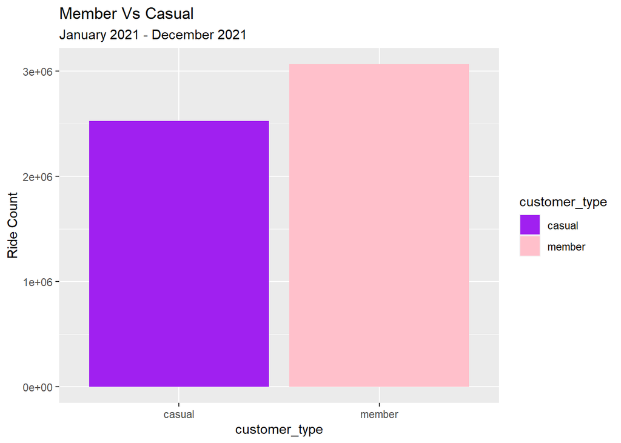

```r
ggplot(data = triprawdata,mapping= aes(x= customer_type, fill =customer_type))+
  scale_fill_manual(values = c("Purple", "pink")) +geom_bar() + ylab('Ride Count')+
  labs(title="Member Vs Casual") + labs(subtitle = "January 2021 - December 2021")
```

### Average Ride behavior of members and casual riders

```
## Defaulting to continuous.
```

[figure not shown]

```r
bar<-triprawdata%>%
  group_by(customer_type)%>%
  summarise(avg_ride_length=mean(ride_length))
ggplot(bar, aes(x = customer_type, y = avg_ride_length, fill =customer_type))+ylab('avg_Ride_Count')+
  geom_col()+ scale_fill_manual(values = c("Purple", "pink"))+
  labs(title="Member Vs Casual") + labs(subtitle = "January 2021 - December 2021")
```

### Comparing Bikes

Ride Type Trends and Count of ride type by user type

```r
triprawdata %>% count(ride_type, customer_type)
```

```
##       ride_type customer_type       n
## 1  classic_bike        casual 1263433
## 2  classic_bike        member 1983034
## 3   docked_bike        casual  312043
## 4   docked_bike        member       1
## 5 electric_bike        casual  949980
## 6 electric_bike        member 1081655
```

```r
triprawdata%>%
  group_by(ride_type) %>%
  summarise(n=n())%>%
  mutate(percent = n*100/sum(n))
```

```
## # A tibble: 3 × 3
##   ride_type           n percent
##   <chr>           <int>   <dbl>
## 1 classic_bike  3246467   58.1
## 2 docked_bike    312044    5.58
## 3 electric_bike 2031635   36.3
```

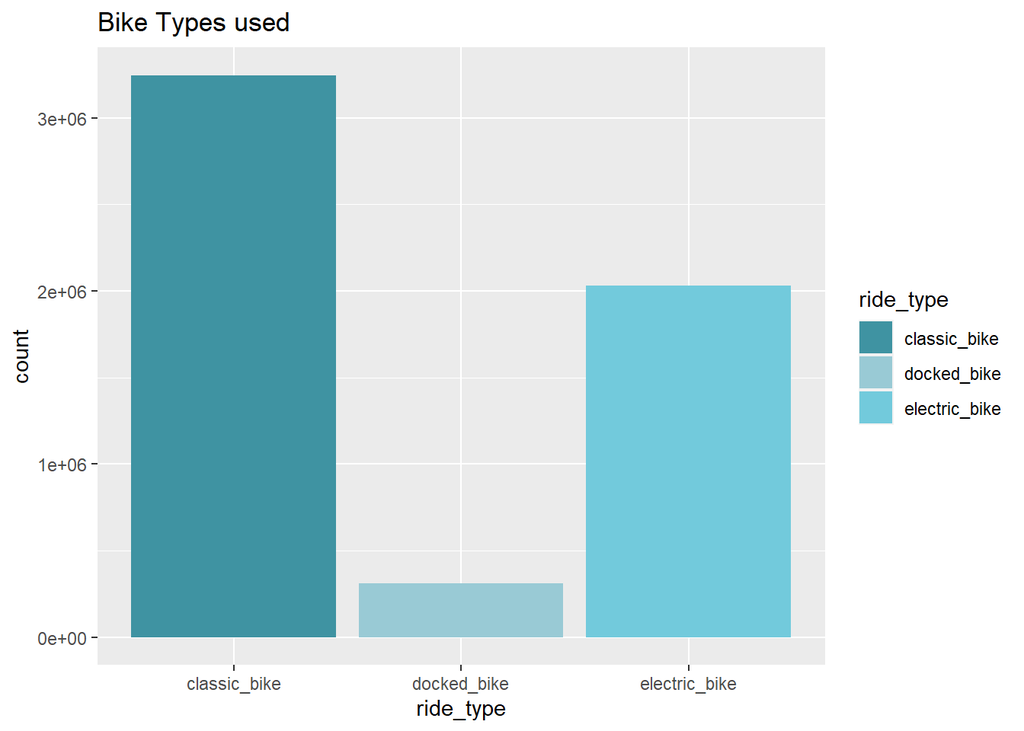

```r
ggplot(data = triprawdata,mapping= aes(x= ride_type,fill=ride_type)) +
  geom_bar() + labs(title="Bike Types used") +
  scale_fill_manual(values = c("#3f93a2", "#99cad5" , "#72CADC"))
```

### Choice of Bikes by Riders

```r
member_type<-triprawdata%>%
  group_by(customer_type,ride_type) %>%
  summarise(n=n())%>%
  mutate(percent = n*100/sum(n))
```

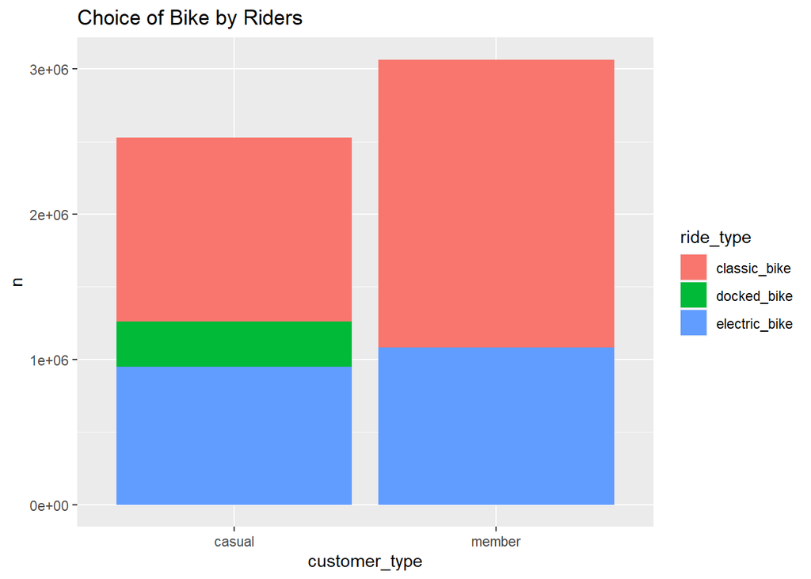

```r
ggplot(data = as.data.frame(member_type),mapping= aes(x= customer_type, y=n, fill =ride_type)) +
  geom_bar(stat = 'identity') + labs(title="Choice of Bike by Riders")
```

### Count of ride type by user type

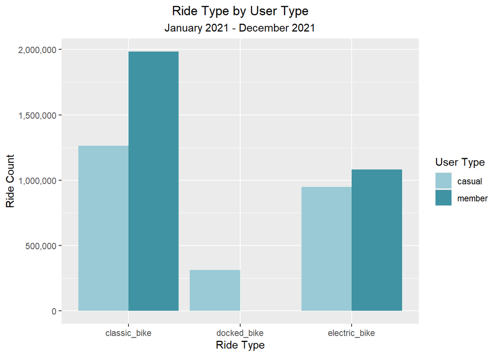

```r
ggplot(triprawdata, aes(x = ride_type, fill = customer_type)) +
  geom_bar(position = "dodge") +
  ggtitle('Ride Type by User Type', subtitle = "January 2021 - December 2021") +
  theme(plot.title = element_text(hjust = 0.5), plot.subtitle = element_text(hjust = 0.5)) +
  xlab('Ride Type') +   ylab('Ride Count') +
  labs(fill='User Type') +
  scale_y_continuous(labels = scales::comma) +
  scale_fill_manual(values = c("#99cad5", "#3f93a2"),
                    labels = c("casual","member"))
```

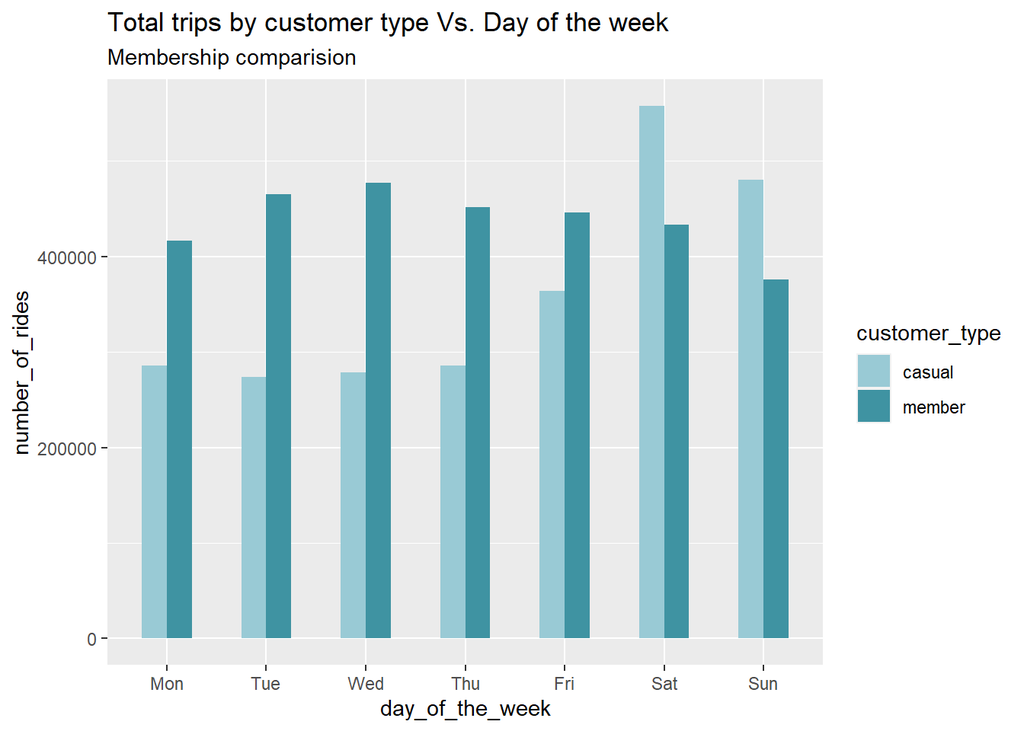

```r
triprawdata %>%
  group_by(customer_type, day_of_the_week) %>%
  summarise(number_of_rides = n()) %>%
  arrange(customer_type, day_of_the_week)  %>%
  ggplot(aes(x = day_of_the_week, y = number_of_rides, fill = customer_type)) +
  labs(title ="Total trips by customer type Vs. Day of the week", subtitle="Membership comparision") +
  geom_col(width=0.5, position = position_dodge(width=0.5)) +
  scale_y_continuous(labels = function(x) format(x, scientific = FALSE)) +
  scale_fill_manual(values = c("#99cad5", "#3f93a2"))
```

### Average number of trips by customer type and month

```r
unique(triprawdata$month)
```

```
##  [1] Jan Feb Mar Apr May Jun Jul Aug Sep Oct Nov Dec
## 12 Levels: Jan < Feb < Mar < Apr < May < Jun < Jul < Aug < Sep < ... < Dec
```

```r
triprawdata %>%
  group_by(customer_type, month) %>%
  summarise(number_of_rides = n(),`average_duration_(mins)` = mean(ride_length)) %>%
  arrange(customer_type,desc(number_of_rides))
```

```
## # A tibble: 24 × 4
## # Groups:   customer_type [2]
##    customer_type month number_of_rides `average_duration_(mins)`
##    <chr>         <ord>           <int> <drtn>
##  1 casual        Jul            441465 31.43585 mins
##  2 casual        Aug            412101 27.41808 mins
##  3 casual        Jun            370153 35.64591 mins
##  4 casual        Sep            363460 26.66751 mins
##  5 casual        Oct            256826 24.17351 mins
##  6 casual        May            256577 36.97601 mins
##  7 casual        Apr            136414 36.60825 mins
##  8 casual        Nov            106755 20.08611 mins
##  9 casual        Mar             83922 36.88100 mins
## 10 casual        Dec             69615 21.28306 mins
## # … with 14 more rows
```

### monthly ride by customers

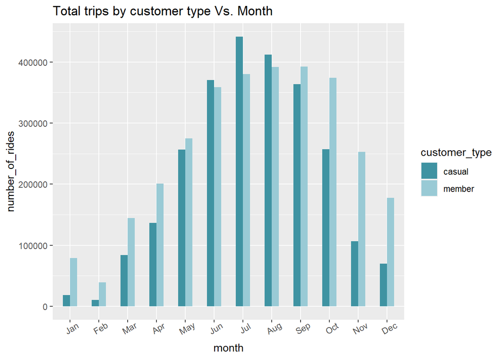

```r
triprawdata %>%
  group_by(customer_type, month) %>%
  summarise(number_of_rides = n()) %>%
  arrange(customer_type, month)  %>%
  ggplot(aes(x = month, y = number_of_rides, fill = customer_type)) +
  labs(title ="Total trips by customer type Vs. Month") +
  theme(axis.text.x = element_text(angle = 30)) +
  geom_col(width=0.5, position = position_dodge(width=0.5)) +
  scale_y_continuous(labels = function(x) format(x, scientific = FALSE)) +
  scale_fill_manual(values = c("#3f93a2", "#99cad5"))
```